# Trait sensitivity analysis

Sylvain Schmitt

2017-03-10

Built with `RconTroll` package version 0.1.9007 available at https://gitlab.com/sylvain.schmitt/RconTroll and `TROLL` package version 0.1.9017 available at https://gitlab.com/sylvain.schmitt/TROLL with R version 3.3.2 (2016-10-31) environment.

# Introduction

To study resistance and resilience of ecosystem face to disturbance, highlighting the role of biodiversity, we decided to use TROLL model simulations (Chave 1999). In order to get a finer study of simulations response, we need to assess first sensitivity of the TROLL model to different parameters. More particularly we need to assess the importance of functional traits to further better control functional diversities in simulations. We also need to assess sensitivity of the model to see rain constant because we assume it is one of the main factor of tree recruitments after disturbance in the model.

# Material and methods

## Functional traits

TROLL model currently encompass following traits:

|  | unit | mean | variance |
| --- | --- | --- | --- |
| LMA | $g.m^-2$ | 1.02e+02 | 8.28e+02 |
| Nmass | m$g.g^-1$ | 2.08e-02 | 2.89e-05 |
| Pmass | $mg.g^-1$ | 6.74e-04 | 1.00e-07 |
| wsg | $g.cm^-3$ | 6.45e-01 | 1.24e-02 |
| dmax | $m$ | 4.88e-01 | 6.05e-02 |
| hmax | $m$ | 5.01e+01 | 3.49e+02 |
| ah | $m$ | 3.23e-01 | 3.93e-02 |
| seedvolume | $mm^3$ | 2.89e+00 | 7.29e+01 |
| Freg | $nb.ha^-1$ | 6.13e-03 | 1.61e-04 |

Table 1: Functional traits of TROLL model species *Traits with their abbreviation, standard unit, mean and variance.*

To assess the sensitivity of TROLL model to species functionnal traits, we performed a sensitivity analysis by fixing species trait values to their mean. Each trait was tested independently. We reduce to a common mean traits with a correlation $r \geq 0.8$ (see figure 1).

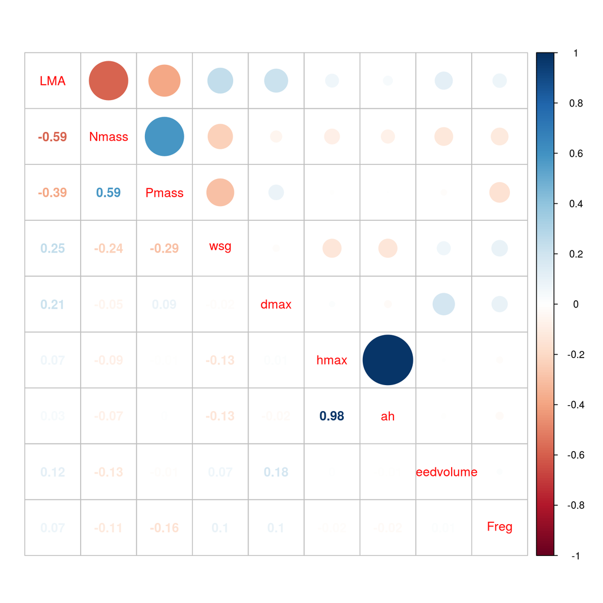

## Seed rain

To assess the sensitivity of TROLL model to seed rain, we performed a sensitivity analysis by fixing simulations seed rain constant to 1%, 10%, 100% and 1000% from is default value.

Simulations were conducted on Intel Xeon(R) with 32 CPUs of 2.00GHz and 188.9 GB of memory. We assumed maturity of the forest after 500 years of regeneration (Maréchaux & Chave) and computed simulation 100 years after a disturbance event of 40% intensity. Due to computer limitations we did not run replicate (besides it should be necessary to reduce simulation stochasticity). To assess ecosystem outputs sensitivity to studied parameters, we compared it to 100 replicates of control simulations with all parameters set to default values. Ecosystem outputs outside of the range of the control replicates values are significantly influenced by the studied parameter.

All analyses were conducted under R version 3.3.2 (2016-10-31) with RconTroll package version 0.1.9007.

# Results

## Control

Both disturbed ecosystem structure and functional composition corresponded to ecosystem structure and functional composition before disturbance (figure 2 & 3). Consequently, we assumed that disturbance did not affect much ecosystem structure and function. Secondly range of values inside control replicates is low (figure 4).

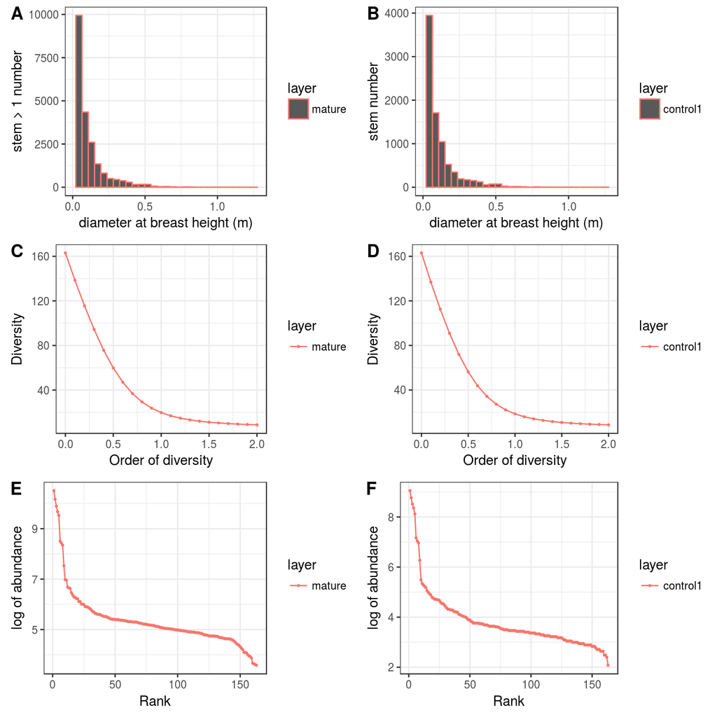

Figure 2. Ecosystem structure before disturbance and disturbed. *Ecosystem structure before disturbance (left) and disturbed (right) with diameter structure (**A**, **B**), diversity at different orders (**C**, **D**) and rank-abundance diagrams (**E**, **F**).*

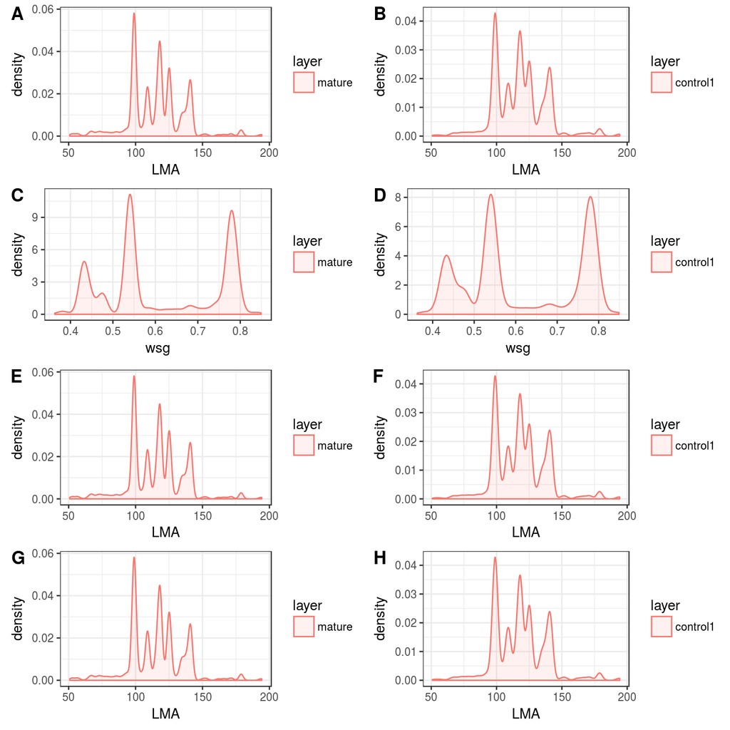

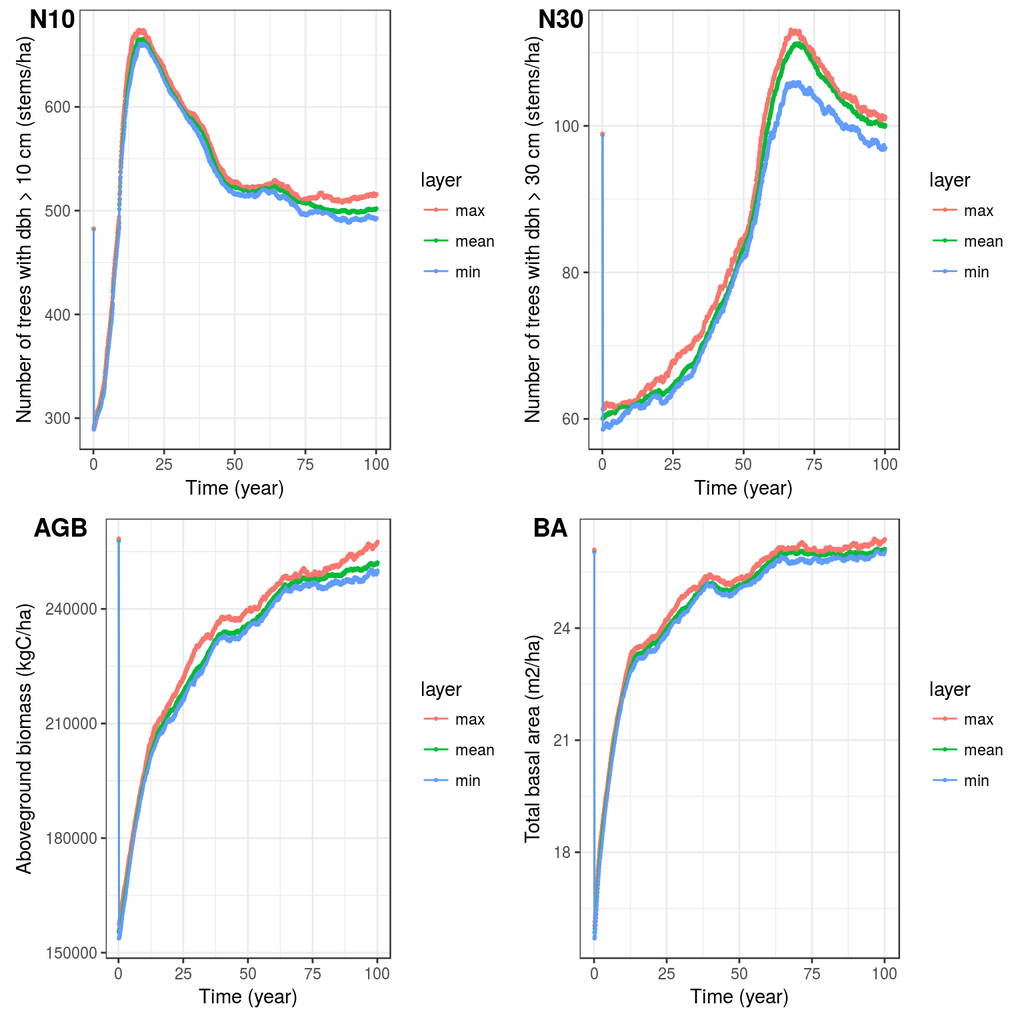

Figure 4. Control replicates variation. *Maximum, mean and minimum number of trees with dbh above 10 cm (**N10**) and 30 cm (**N30**), above ground biomass (**AGB**) and basal area (**BA**) over simulation time.*

## Functional traits

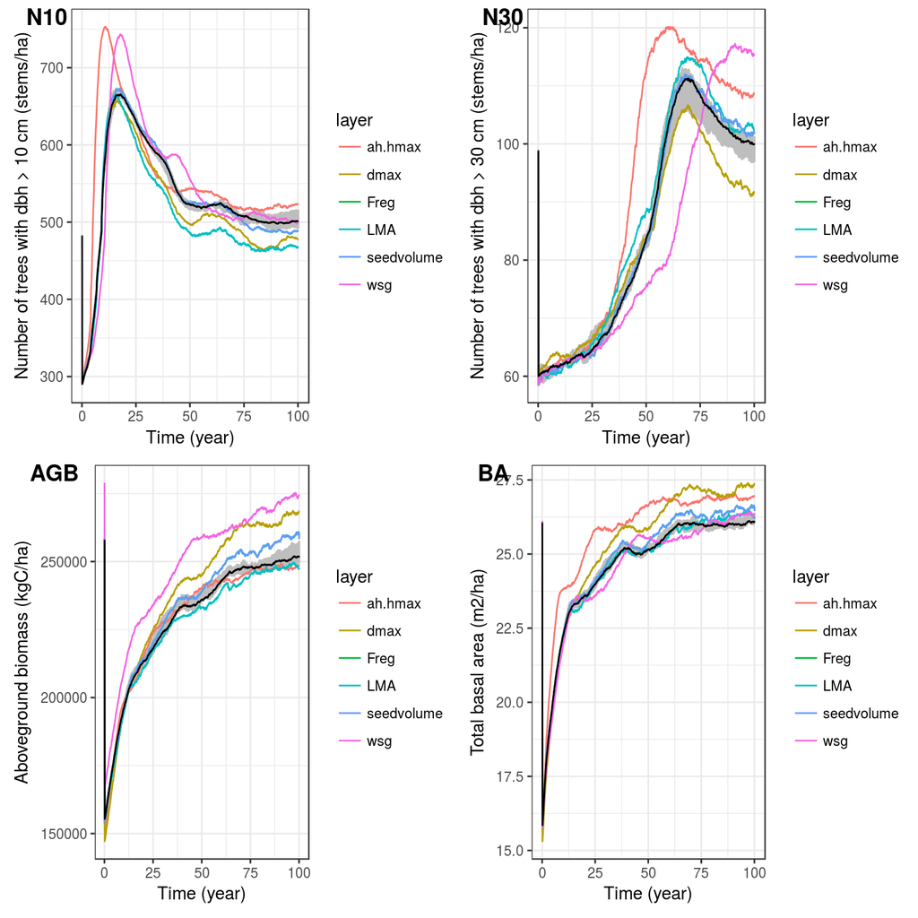

Figure 5. Traits variation. *Number of trees with dbh above 10 cm (**N10**) and 30 cm (**N30**), above ground biomass (**AGB**) and basal area (**BA**).*

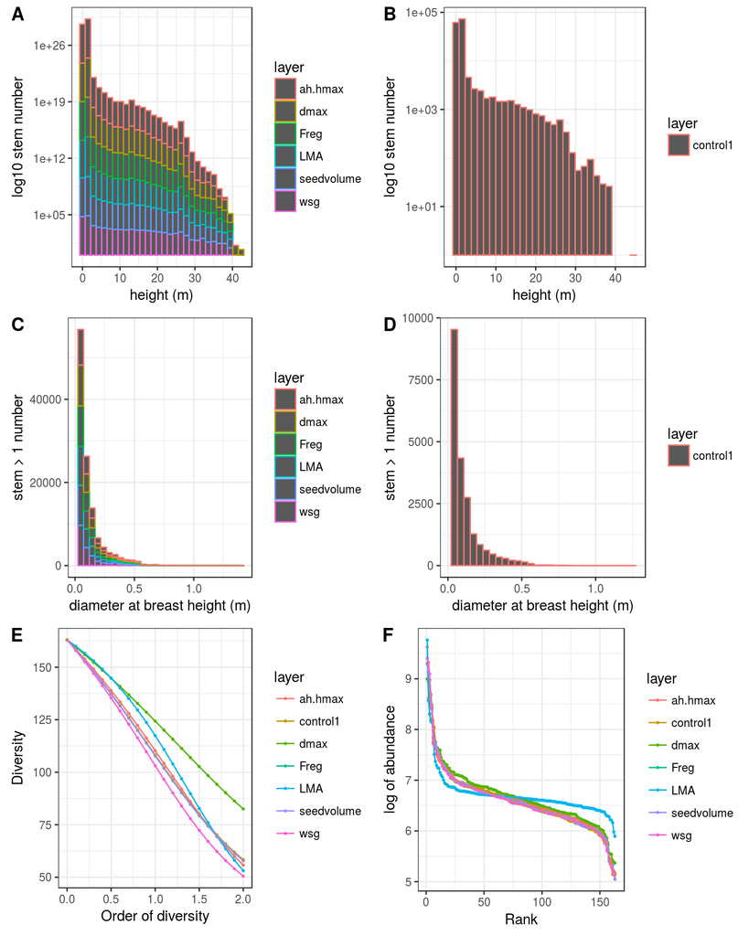

Figure 6. Traits structure. *Tree final height histogram for traits (**A**) and control (**B**), tree final diameter histogram for traits (**C**) and control (**D**), ecosystem final diversity plot at different orders (**E**), and ecosystem final rank-abundance diagram (**F**).*

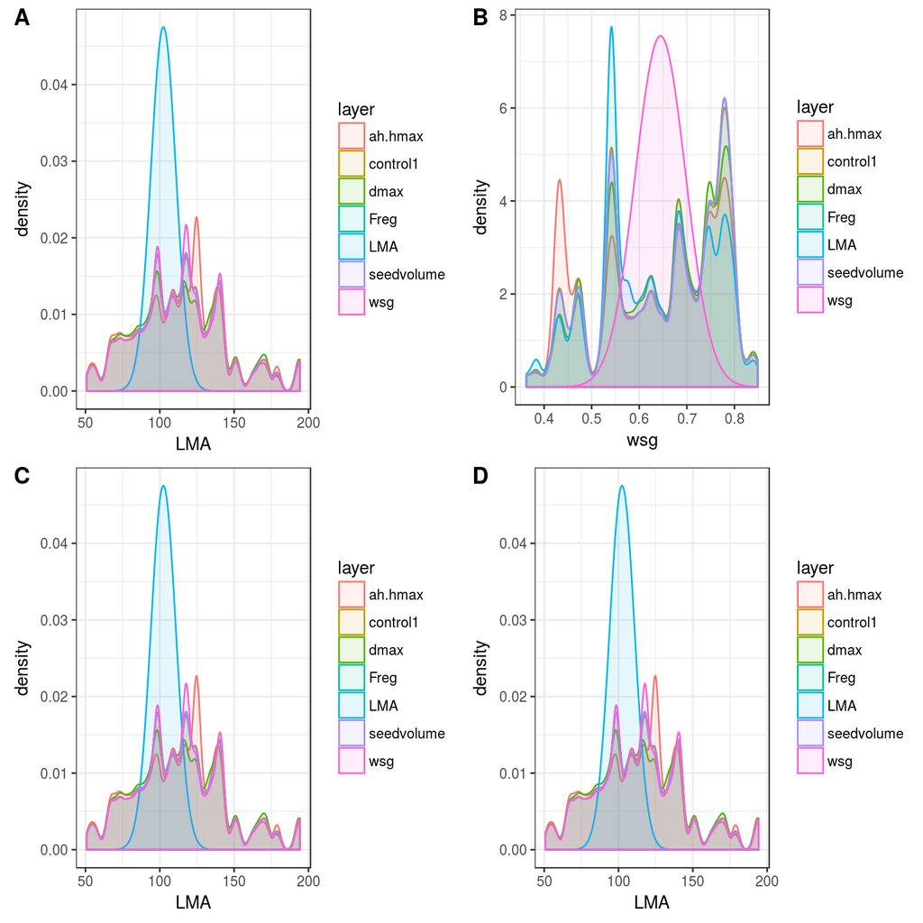

## Seed rain

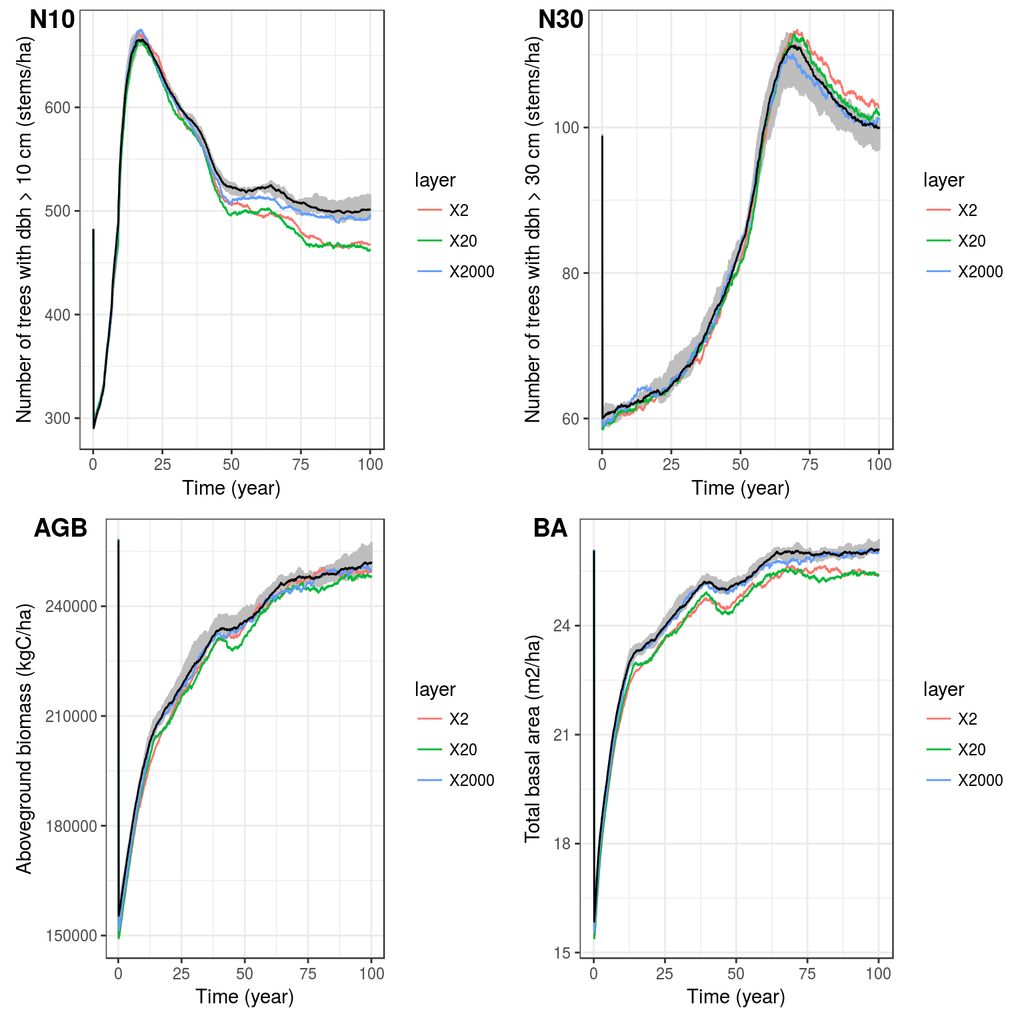

Figure 8. Seedrain variation. *Number of trees with dbh above 10 cm (**N10**) and 30 cm (**N30**), above ground biomass (**AGB**) and basal area (**BA**).*

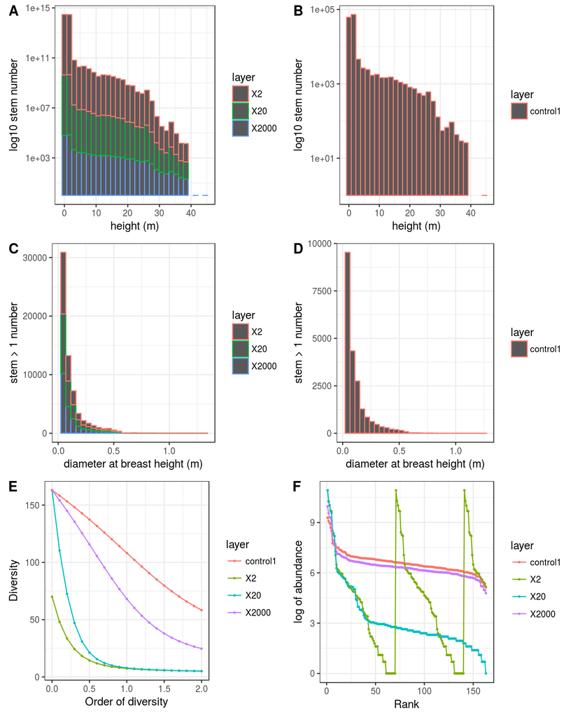

Figure 9. Seedrain structure. *Tree final height histogram for traits (**A**) and control (**B**), tree final diameter histogram for traits (**C**) and control (**D**), ecosystem final diversity plot at different orders (**E**), and ecosystem final rank-abundance diagram (**F**).*

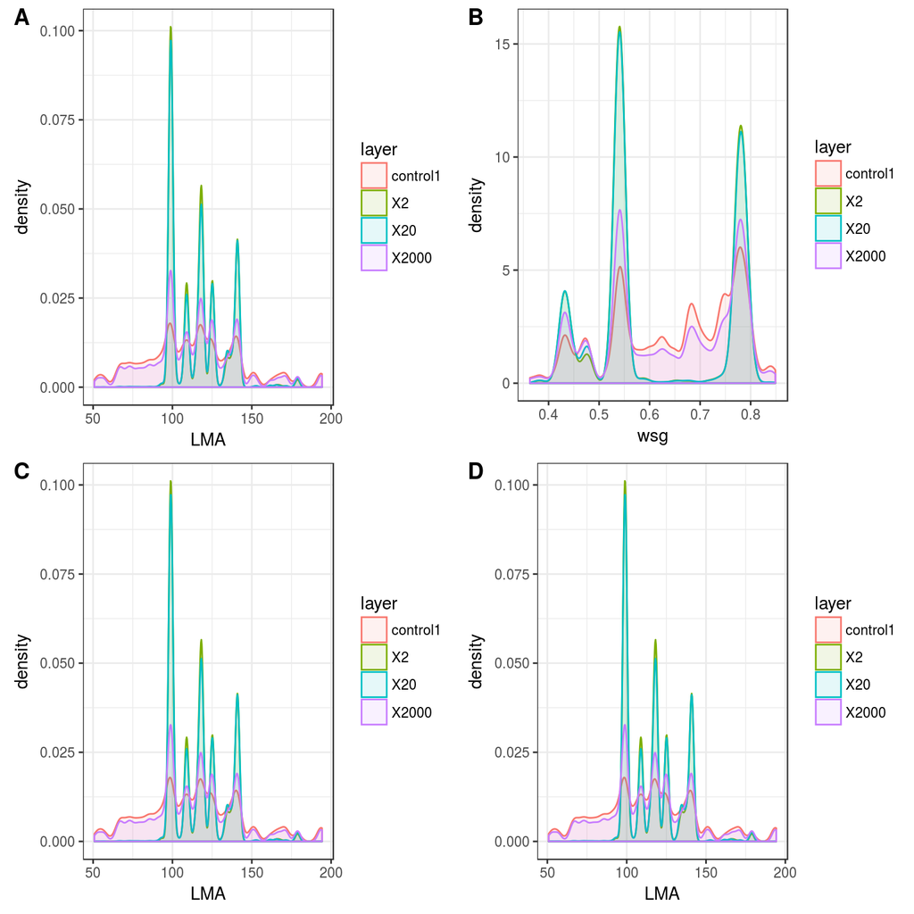

# Discussion

## Disturbance simulation

Ecosystem structure, species organisation and functional composition stayed the same before and after disturbance. We can thus validate disturbance module in its actual state. Morevoer we can now consider that the composition we will initialise at the beginning of simulations will stay the same after disturbance. Finally control replicates has shown few stochasticity, it advocates for few or no replicates in further analysis.

## Functional traits selection

**ah-hmax** fixed to mean implied no high or low trees. Less high trees left space for more trees increasing number of stems in the ecosystem thus increasing basal area. **wsg** fixed to mean mainly increased wood density of light wood species. Globally higher wood density increased lifespan of individuals responsible for the time lag and the higher number of stems increasing basal area. **wsg** fiwed to mean also increased carbon capture by individuals, thus increasing aboveground biomass. **dmax** fixed to mean decreased death rates. Decreased death rate diminished number of stems, expecially big ones thus increasing global basal area and abiveground biomass. **dmax** fixed to mean by keeping more small diameter stems also increased random selection of species increasing eveness in species distribution.

## Seed rain constant influence

Seedrain constant did not directly affect ecosystem global outputs over simulation post-disturbance time but have a major effect on species and functional composition and diversity. Reducing seedrain constant resulted in an ecosystem selecting few species increasing their abundance and functional dominance of their traits. Thus reduced seedrain constant greatly diminsihed eveness untill a decrease of total number of species for its lowest value. Consequently seedrain constant fixed to a low value seemed to unstabilized ecosystem (with number of stems above 10 cm dbh decreasing under the pre-disturbance value).

# References

Chave, J. (1999). Study of structural, successional and spatial patterns in tropical rain forests using TROLL, a spatially explicit forest model. *Ecological Modelling*, **124**, 233–254.

Maréchaux, I. & Chave, J. Joint simulation of carbon and tree diversity in an Amazonian forest with an individual-based forest model. *Inprep*, 1–13.